# Untitled

```r
library(dplyr)
library(TTR)
library(forecast)
library(lmtest)
library(orcutt)
library(HoRM)
```

# Soal 1

## Data

```r
data_sales <- data.frame(
  Year = c(1975:2014),
  Sales = c(11.7, 12.0, 12.3, 12.8, 13.1, 13.6, 13.9, 14.4, 14.7, 15.3,
            15.5, 15.8, 16.1, 16.6, 16.9, 16.7, 16.9, 17.4, 17.6, 17.9,
            18.0, 17.9, 18.0, 18.2, 18.2, 18.3, 18.6, 19.2, 19.3, 19.5,
            19.2, 19.3, 19.5, 20.0, 20.0, 19.9, 19.8, 19.9, 20.2, 21.0),
  Advertising = c(9.4, 9.6, 10.0, 10.4, 10.8, 10.9, 11.7, 12.2, 12.5, 12.9,
                  13.0, 13.2, 13.8, 14.2, 14.6, 14.4, 15.0, 15.4, 15.7, 15.9,
                  15.9, 16.0, 16.3, 16.2, 16.8, 17.3, 17.6, 18.1, 18.3, 18.5,
                  18.7, 18.9, 19.2, 20.0, 20.0, 20.3, 20.4, 21.0, 21.5, 22.1)
)
```

## Model Awal

```r
model <- lm(Sales ~ Advertising, data = data_sales)
summary(model)
```

```
##
## Call:
## lm(formula = Sales ~ Advertising, data = data_sales)
##
## Residuals:
##      Min       1Q   Median       3Q      Max
## -1.03758 -0.40343  0.08933  0.45674  0.74036
##
## Coefficients:
##             Estimate Std. Error t value Pr(>|t|)
## (Intercept)  5.96513    0.38092   15.66   <2e-16 ***
## Advertising  0.71035    0.02365   30.04   <2e-16 ***
## ---
## Signif. codes:  0 '***' 0.001 '**' 0.01 '*' 0.05 '.' 0.1 ' ' 1
##
## Residual standard error: 0.527 on 38 degrees of freedom
## Multiple R-squared:  0.9596, Adjusted R-squared:  0.9585
## F-statistic: 902.3 on 1 and 38 DF,  p-value: < 2.2e-16
```

## Pengecekan Asumsi

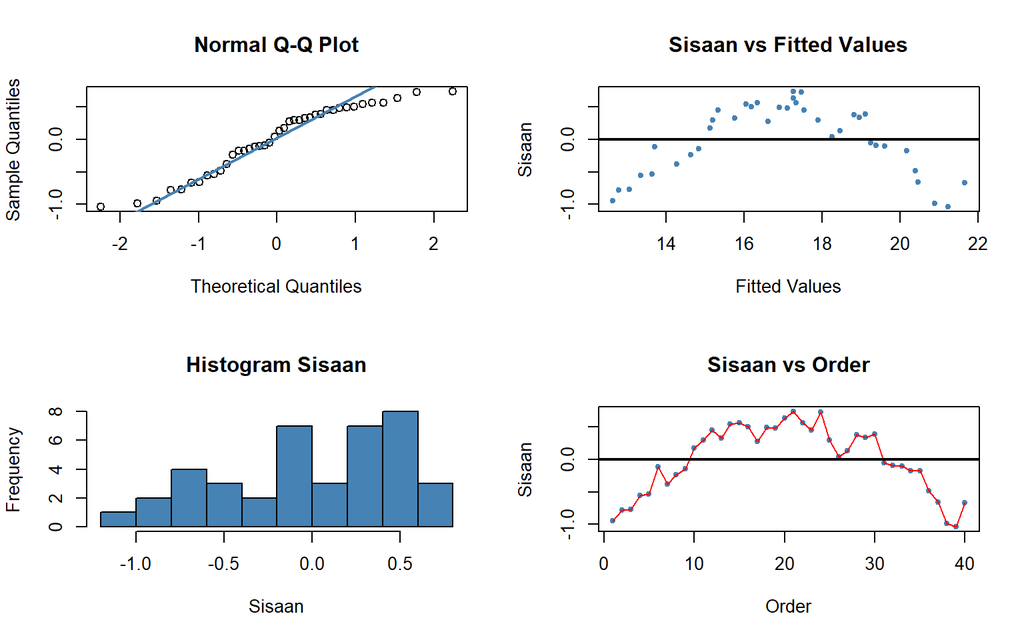

```r
# Hitung sisaan dan fitted values dari model Anda
sisaan <- residuals(model)
fitValue <- fitted(model)

# Diagnostik dengan eksploratif
par(mfrow = c(2, 2))

# 1. Normal Q-Q Plot
qqnorm(sisaan)
qqline(sisaan, col = "steelblue", lwd = 2)

# 2. Sisaan vs Fitted Values (Label sudah dibetulkan)
plot(fitValue, sisaan, col = "steelblue", pch = 20, xlab = "Fitted Values", ylab = "Sisaan", main = "Sisaan vs Fitted Values")
abline(a = 0, b = 0, lwd = 2)

# 3. Histogram Sisaan
hist(sisaan, col = "steelblue", main = "Histogram Sisaan", xlab = "Sisaan")

# 4. Sisaan vs Order (Panjang x diubah otomatis sesuai jumlah sisaan)
n_data <- length(sisaan)
plot(seq(1, n_data, 1), sisaan, col = "steelblue", pch = 20, xlab = "Order", ylab = "Sisaan", main = "Sisaan vs Order")
lines(seq(1, n_data, 1), sisaan, col = "red")
abline(a = 0, b = 0, lwd = 2)
```

```r
# Kembalikan layout plot ke normal (1x1)
par(mfrow = c(1, 1))
```

```r
dwtest(model)
```

```
##
##  Durbin-Watson test
##
## data:  model
## DW = 0.16204, p-value < 2.2e-16
## alternative hypothesis: true autocorrelation is greater than 0
```

Berdasarkan hasil uji Durbin-Watson pada model, diperoleh nilai statistik $DW = 0.16204$ dengan $p\text{-value} < 2.2 \times 10^{-16}$. Karena nilai $p\text{-value}$ jauh lebih kecil dari taraf nyata $\alpha = 0.05$, maka diputuskan untuk menolak $H_0$. Hal ini menunjukkan bahwa terdapat bukti yang sangat kuat bahwa terdapat autokorelasi positif yang sangat tinggi pada sisaan model regresi awal.

## Penanganan autokorleasi menggunakan Cochrane Orcutt

```r
modelCO<-cochrane.orcutt(model)
modelCO
```

```
## Cochrane-orcutt estimation for first order autocorrelation
##
## Call:
## lm(formula = Sales ~ Advertising, data = data_sales)
##
##  number of interaction: 39
##  rho 0.903123
##
## Durbin-Watson statistic
## (original):    0.16204 , p-value: 8.935e-20
## (transformed): 1.93925 , p-value: 3.78e-01
##
##  coefficients:
## (Intercept) Advertising
##   10.252375    0.488489
```

Berdasarkan hasil estimasi Cochrane-Orcutt, model awal yang semula mengalami masalah autokorelasi positif kuat ($DW = 0.16204$, $p$-value $< 0.05$) berhasil ditangani. Setelah dilakukan transformasi dengan nilai $\rho = 0.903123$, diperoleh statistik Durbin-Watson yang baru sebesar $DW = 1.93925$ dengan $p$-value $= 0.378$ ($\alpha > 0.05$). Hal ini menunjukkan bahwa asumsi bebas autokorelasi telah terpenuhi. Persamaan regresi akhir yang terbentuk adalah $\text{Sales} = 10.252375 + 0.488489(\text{Advertising})$.

## Penanganan autokorleasi menggunakan Hildreth-Lu

```r
library(HoRM)

# Ambil y (Sales) dan x (Advertising satu prediktor)
y <- data_sales$Sales
x <- data_sales$Advertising

# Grid search rho dari 0 sampai 0.9 dengan interval 0.1
r <- seq(0, 0.9, by = 0.001)
tab <- data.frame(
  rho = r,
  SSE = sapply(r, function(rr) deviance(hildreth.lu(y, x, rr)))
)

# Menampilkan tabel hasil SSE untuk setiap nilai rho
tab
```

```
##       rho      SSE
## 1   0.000 9.561851
## 2   0.001 9.543695
## 3   0.002 9.525560
## 4   0.003 9.507445
## 5   0.004 9.489350
## 6   0.005 9.471275
## 7   0.006 9.453220
## 8   0.007 9.435185
## 9   0.008 9.417170
## 10  0.009 9.399175
## 11  0.010 9.381200
## 12  0.011 9.363246
## 13  0.012 9.345311
## 14  0.013 9.327397
```

[output cut: 887 more lines]

```r
rho_hat <- tab$rho[which.min(tab$SSE)]   # rho terbaik
fit_hl  <- hildreth.lu(y, x, rho_hat)    # model final
summary(fit_hl)
```

```
##
## Call:
## lm(formula = y ~ x)
##
## Residuals:
##     Min      1Q  Median      3Q     Max
## -0.3749 -0.1461  0.0148  0.1057  0.4496
##
## Coefficients:
##             Estimate Std. Error t value Pr(>|t|)
## (Intercept)  1.01310    0.14198   7.135 1.87e-08 ***
## x            0.49358    0.07379   6.689 7.38e-08 ***
## ---
## Signif. codes:  0 '***' 0.001 '**' 0.01 '*' 0.05 '.' 0.1 ' ' 1
##
## Residual standard error: 0.1868 on 37 degrees of freedom
## Multiple R-squared:  0.5474, Adjusted R-squared:  0.5351
## F-statistic: 44.74 on 1 and 37 DF,  p-value: 7.382e-08
```

```r
dwtest(fit_hl)
```

```
##
##  Durbin-Watson test
##
## data:  fit_hl
## DW = 1.9402, p-value = 0.3782
## alternative hypothesis: true autocorrelation is greater than 0
```

Berdasarkan hasil estimasi menggunakan metode Hildreth-Lu, model regresi akhir yang diperoleh berhasil mengatasi masalah autokorelasi. Hal ini dibuktikan melalui uji Durbin-Watson yang menghasilkan nilai $DW = 1.9402$ dengan $p\text{-value} = 0.3782$ ($\alpha > 0.05$), yang berarti sisaan model sudah saling bebas (tidak ada autokorelasi). Persamaan regresi akhir yang terbentuk adalah $\hat{y} = 1.01310 + 0.49358x$

## Perbandingan

```r
# Pastikan nama model Anda sesuai:
# 1. model = model awal (sebelum penanganan)
# 2. model_co  = model dari Cochrane-Orcutt (package orcutt)
# 3. model_final_hl = model dari Hildreth-Lu

# Menghitung Sum of Squared Errors (SSE) untuk masing-masing model
sseModelawal <- anova(model)$`Sum Sq`[-1]
sseModelCO   <- sum(residuals(modelCO)^2)       # Mengambil SSE dari Cochrane-Orcutt
sseModelHL   <- anova(fit_hl)$`Sum Sq`[-1]

# Menghitung Mean Squared Error (MSE) dengan membagi SSE dengan jumlah data (n = 40)
n <- length(data_sales$Sales)
mseModelawal <- sseModelawal / n
mseModelCO   <- sseModelCO / n
mseModelHL   <- sseModelHL / n

# Membuat matriks rangkuman akurasi
akurasi <- matrix(c(sseModelawal, sseModelCO, sseModelHL,
                    mseModelawal, mseModelCO, mseModelHL),
                  nrow = 2, ncol = 3, byrow = TRUE)

colnames(akurasi) <- c("Model Awal", "Model Cochrane-Orcutt", "Model Hildreth-Lu")
row.names(akurasi) <- c("SSE", "MSE")

# Menampilkan tabel hasil
akurasi
```

```
##     Model Awal Model Cochrane-Orcutt Model Hildreth-Lu
## SSE 10.5545322             60.613260        1.29139494
## MSE  0.2638633              1.515331        0.03228487
```

Berdasarkan perbandingan menggunakan Sum of Squared Errors (SSE) dan Mean Squared Error (MSE), Model Hildreth-Lu merupakan model terbaik karena menghasilkan nilai kesalahan prediksi yang paling minimum (SSE = 1.29139, MSE = 0.03228). Sementara itu, metode Cochrane-Orcutt pada kasus ini menghasilkan kesalahan yang lebih tinggi dibanding model awal.

# Soal 2

## Data

```r
data_market <- data.frame(
  Period = c(1:20),
  Market_share = c(
    3.63, 4.20, 3.33, 4.54, 2.89, 4.87, 4.90, 5.29, 6.18, 7.20,
    7.25, 6.09, 6.80, 8.65, 8.43, 8.29, 7.18, 7.90, 8.45, 8.23
  ),
  Price = c(
    0.97, 0.95, 0.99, 0.91, 0.98, 0.90, 0.89, 0.86, 0.85, 0.82,
    0.79, 0.83, 0.81, 0.77, 0.76, 0.80, 0.83, 0.79, 0.76, 0.78
  )
)

head(data_market)
```

```
##   Period Market_share Price
## 1      1         3.63  0.97
## 2      2         4.20  0.95
## 3      3         3.33  0.99
## 4      4         4.54  0.91
## 5      5         2.89  0.98
## 6      6         4.87  0.90
```

## Model Awal

```r
model2 <- lm(Market_share ~ Price, data = data_market)
summary(model2)
```

```
##
## Call:
## lm(formula = Market_share ~ Price, data = data_market)
##
## Residuals:
##      Min       1Q   Median       3Q      Max
## -0.73068 -0.29764 -0.00966  0.30224  0.81193
##
## Coefficients:
##             Estimate Std. Error t value Pr(>|t|)
## (Intercept)   26.910      1.110   24.25 3.39e-15 ***
## Price        -24.290      1.298  -18.72 3.02e-13 ***
## ---
## Signif. codes:  0 '***' 0.001 '**' 0.01 '*' 0.05 '.' 0.1 ' ' 1
##
## Residual standard error: 0.4287 on 18 degrees of freedom
## Multiple R-squared:  0.9511, Adjusted R-squared:  0.9484
## F-statistic: 350.3 on 1 and 18 DF,  p-value: 3.019e-13
```

## Pengecekan Asumsi

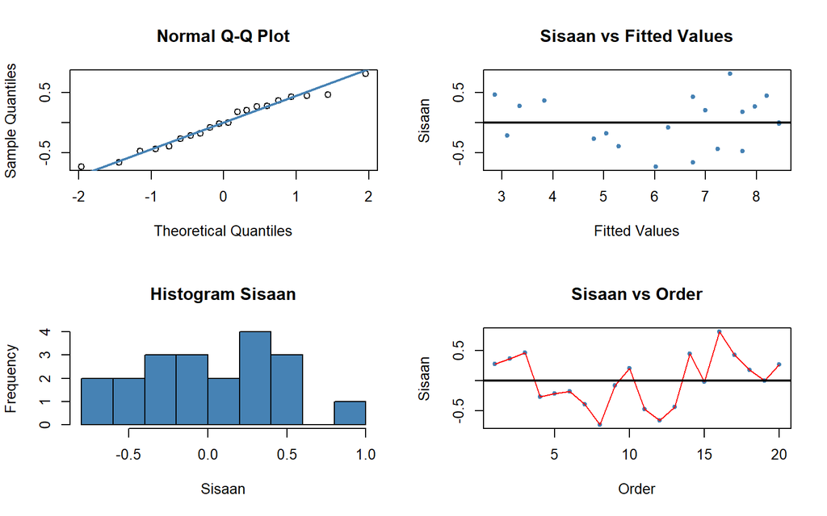

```r
sisaan2 <- residuals(model2)
fitValue2 <- fitted(model2)

par(mfrow = c(2, 2))
qqnorm(sisaan2)
qqline(sisaan2, col = "steelblue", lwd = 2)

plot(fitValue2, sisaan2, col = "steelblue", pch = 20, xlab = "Fitted Values", ylab = "Sisaan", main = "Sisaan vs Fitted Values")
abline(a = 0, b = 0, lwd = 2)

hist(sisaan2, col = "steelblue", main = "Histogram Sisaan", xlab = "Sisaan")

n_data <- length(sisaan2)
plot(seq(1, n_data, 1), sisaan2, col = "steelblue", pch = 20, xlab = "Order", ylab = "Sisaan", main = "Sisaan vs Order")
lines(seq(1, n_data, 1), sisaan2, col = "red")
abline(a = 0, b = 0, lwd = 2)
```

```r
par(mfrow = c(1, 1))
```

```r
dwtest(model2)
```

```
##
##  Durbin-Watson test
##
## data:  model2
## DW = 1.1358, p-value = 0.009813
## alternative hypothesis: true autocorrelation is greater than 0
```

Berdasarkan hasil uji Durbin-Watson pada model awal, diperoleh nilai statistik $DW = 1.1358$ dengan $p\text{-value} = 0.009813$. Karena nilai $p\text{-value}$ lebih kecil dari taraf nyata $\alpha = 0.05$, maka diputuskan untuk menolak $H_0$. Hal ini menunjukkan bahwa terdapat bukti yang cukup untuk menyimpulkan bahwa terdapat autokorelasi positif pada sisaan model regresi

## Penanganan autokorleasi menggunakan Cochrane Orcutt

```r
modelCO2 <- cochrane.orcutt(model2)
modelCO2
```

```
## Cochrane-orcutt estimation for first order autocorrelation
##
## Call:
## lm(formula = Market_share ~ Price, data = data_market)
##
##  number of interaction: 8
##  rho 0.425232
##
## Durbin-Watson statistic
## (original):    1.13582 , p-value: 9.813e-03
## (transformed): 1.95804 , p-value: 4.151e-01
##
##  coefficients:
## (Intercept)       Price
##    26.72209   -24.08413
```

Berdasarkan hasil estimasi Cochrane-Orcutt, model awal yang semula terdeteksi mengalami autokorelasi positif ($DW = 1.13582$, $p$-value $< 0.05$) berhasil ditangani. Setelah dilakukan transformasi menggunakan nilai $\rho = 0.425232$ dalam 8 iterasi, diperoleh statistik Durbin-Watson yang baru sebesar $DW = 1.95804$ dengan $p$-value $= 0.4151$ ($\alpha > 0.05$). Hal ini menunjukkan bahwa asumsi bebas autokorelasi telah terpenuhi. Persamaan regresi akhir yang terbentuk adalah $\text{Market\_share} = 26.72209 - 24.08413(\text{Price})$.

## Penanganan autokorleasi menggunakan Hildreth-Lu

```r
library(HoRM)

y <- data_market$Market_share
x <- data_market$Price

# Menggunakan r2 dan konsisten memanggil r2 di sapply
r2 <- seq(0, 0.9, by = 0.001)
tab <- data.frame(
  rho = r2,
  SSE = sapply(r2, function(rr) deviance(hildreth.lu(y, x, rr)))
)

head(tab)
```

```
##     rho      SSE
## 1 0.000 3.212112
## 2 0.001 3.209460
## 3 0.002 3.206815
## 4 0.003 3.204177
## 5 0.004 3.201545
## 6 0.005 3.198919
```

```r
rho_hat2 <- tab$rho[which.min(tab$SSE)]   # rho terbaik
fit_hl2  <- hildreth.lu(y, x, rho_hat2)    # model final (menggunakan rho_hat2)
summary(fit_hl2)
```

```
##
## Call:
## lm(formula = y ~ x)
##
## Residuals:
##      Min       1Q   Median       3Q      Max
## -0.55517 -0.25066 -0.05505  0.25010  0.83017
##
## Coefficients:
##             Estimate Std. Error t value Pr(>|t|)
## (Intercept)  15.3655     0.9387   16.37 7.68e-12 ***
## x           -24.0848     1.9380  -12.43 5.88e-10 ***
## ---
## Signif. codes:  0 '***' 0.001 '**' 0.01 '*' 0.05 '.' 0.1 ' ' 1
##
## Residual standard error: 0.3955 on 17 degrees of freedom
## Multiple R-squared:  0.9008, Adjusted R-squared:  0.895
## F-statistic: 154.4 on 1 and 17 DF,  p-value: 5.88e-10
```

```r
dwtest(fit_hl2)
```

```
##
##  Durbin-Watson test
##
## data:  fit_hl2
## DW = 1.9577, p-value = 0.4148
## alternative hypothesis: true autocorrelation is greater than 0
```

Berdasarkan hasil estimasi menggunakan metode Hildreth-Lu, model regresi akhir yang diperoleh berhasil mengatasi masalah autokorelasi. Hal ini dibuktikan melalui uji Durbin-Watson yang menghasilkan nilai $DW = 1.9577$ dengan $p\text{-value} = 0.4148$ ($\alpha > 0.05$), yang berarti sisaan model sudah saling bebas dari autokorelasi. Persamaan regresi akhir yang terbentuk adalah $\hat{y} = 15.3655 - 24.0848x$ dengan koefisien determinasi yang sangat tinggi yaitu $R^2 = 90.08\%$.

## Perbandingan

```r
sseModelawal2 <- anova(model2)$`Sum Sq`[-1]
sseModelCO2   <- sum(residuals(modelCO2)^2)
sseModelHL2   <- anova(fit_hl2)$`Sum Sq`[-1]

n <- length(data_market$Market_share)
mseModelawal2 <- sseModelawal2 / n
mseModelCO2   <- sseModelCO2 / n
mseModelHL2   <- sseModelHL2 / n

# Matriks akurasi menggunakan variabel berakhiran '2'
akurasi <- matrix(c(sseModelawal2, sseModelCO2, sseModelHL2,
                    mseModelawal2, mseModelCO2, mseModelHL2),
                  nrow = 2, ncol = 3, byrow = TRUE)

colnames(akurasi) <- c("Model Awal", "Model Cochrane-Orcutt", "Model Hildreth-Lu")
row.names(akurasi) <- c("SSE", "MSE")

akurasi
```

```
##     Model Awal Model Cochrane-Orcutt Model Hildreth-Lu
## SSE  3.3082574              3.316041         2.6593683
## MSE  0.1654129              0.165802         0.1329684
```

Berdasarkan perbandingan model menggunakan Sum of Squared Errors (SSE) dan Mean Squared Error (MSE), Model Hildreth-Lu adalah model terbaik karena menghasilkan tingkat kesalahan prediksi yang paling minimum (SSE = 2.65937, MSE = 0.13297).